# projectUnit3_Premani

We shall try to improve the overall model by finding the intersection point of the precision-recall curve vs threshold.

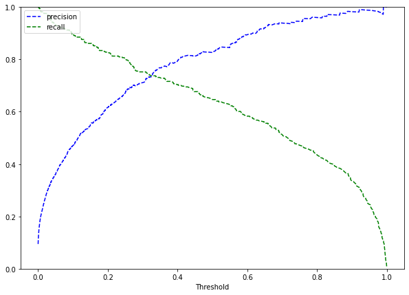

```python
# Find the predicted probabilities for class 1
y_scores = lg.predict_proba(X_train)[:, 1]
# Find fpr, tpr and threshold values
prec, rec, thre = precision_recall_curve(y_train, y_scores,)

def plot_prec_recall_vs_tresh(precisions, recalls, thresholds):
    plt.plot(thresholds, precisions[:-1], "b--", label="precision")
    plt.plot(thresholds, recalls[:-1], "g--", label="recall")
    plt.xlabel("Threshold")
    plt.legend(loc="upper left")
    plt.ylim([0, 1])

plt.figure(figsize=(10, 7))
# Plot recall precision curve
plot_prec_recall_vs_tresh(prec, rec, thre)
plt.show()
```

The above graph suggests that the optimal threshold where recall and precision are both optimized are at threshold ~= 0.32. At this point, recall=precision ~= 0.74.

```python
# setting the threshold
optimal_threshold_curve = 0.32
```

```
Train data performance:
```

|  | Accuracy | Recall | Precision | F1 |
| --- | --- | --- | --- | --- |
| 0 | 0.95 | 0.740181 | 0.733533 | 0.736842 |

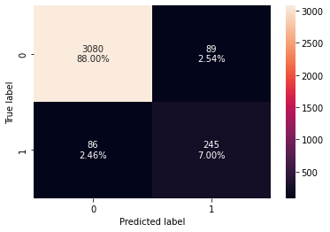

```python
# creating confusion matrix
confusion_matrix_sklearn_with_threshold(lg, X_train, y_train, threshold=optimal_threshold_curve)

log_reg_model_train_perf_threshold_curve = model_performance_classification_sklearn_with_threshold(
    lg, X_train, y_train, threshold=optimal_threshold_curve)

print("Train data performance:")
log_reg_model_train_perf_threshold_curve
```

```
Test data performance:
```

|  | Accuracy | Recall | Precision | F1 |
| --- | --- | --- | --- | --- |
| 0 | 0.942667 | 0.66443 | 0.733333 | 0.697183 |

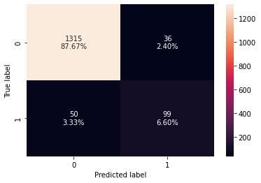

```python
# Test Data Performance
confusion_matrix_sklearn_with_threshold(lg, X_test, y_test, threshold=optimal_threshold_curve)
log_reg_model_test_perf_threshold_curve  = model_performance_classification_sklearn_with_threshold(lg, X_test, y_test,threshold=optimal_threshold_curve)

print("Test data performance:")
log_reg_model_test_perf_threshold_curve
```

Test Data Recall has jumped back a few points, and there is a bigger difference in recall between test and train data, but this threshold value is still better than 0.50. Let's compare all the models we created.

```python
# training performance comparison

models_train_comp_df = pd.concat(
    [
        log_reg_model_train_perf.T,
        log_reg_model_train_perf_threshold_auc_roc.T,
        log_reg_model_train_perf_threshold_curve.T,
    ],
    axis=1,
)
models_train_comp_df.columns = [
    "Logistic Regression sklearn - 0.50 Threshold",
    "Logistic Regression - 0.122 Threshold",
    "Logistic Regression - 0.32 Threshold",
]
print("Training performance comparison:")
models_train_comp_df
```

```
Training performance comparison:
```

|  | Logistic Regression sklearn - 0.50 Threshold | Logistic Regression - 0.122 Threshold | Logistic Regression - 0.32 Threshold |
| --- | --- | --- | --- |
| Accuracy | 0.953714 | 0.910857 | 0.950000 |
| Recall | 0.646526 | 0.882175 | 0.740181 |
| Precision | 0.826255 | 0.516814 | 0.733533 |
| F1 | 0.725424 | 0.651786 | 0.736842 |

```python
# test performance comparison

models_test_comp_df = pd.concat(
    [
        log_reg_model_test_perf.T,
        log_reg_model_test_perf_threshold_auc_roc.T,
        log_reg_model_test_perf_threshold_curve.T,
    ],
    axis=1,
)
models_test_comp_df.columns = [
    "Logistic Regression sklearn - 0.50 Threshold",
    "Logistic Regression - 0.122 Threshold",
    "Logistic Regression - 0.32 Threshold",
]
print("Test performance comparison:")
models_test_comp_df
```

```
Test performance comparison:
```

|  | Logistic Regression sklearn - 0.50 Threshold | Logistic Regression - 0.122 Threshold | Logistic Regression - 0.32 Threshold |
| --- | --- | --- | --- |
| Accuracy | 0.944667 | 0.908667 | 0.942667 |
| Recall | 0.563758 | 0.859060 | 0.664430 |
| Precision | 0.823529 | 0.524590 | 0.733333 |
| F1 | 0.669323 | 0.651399 | 0.697183 |

```python
# Try threshold of 0.25 to strike a balance
manual_optimal_threshold = 0.25
```

```
Train data performance:
```

|  | Accuracy | Recall | Precision | F1 |
| --- | --- | --- | --- | --- |
| 0 | 0.944286 | 0.803625 | 0.671717 | 0.731774 |

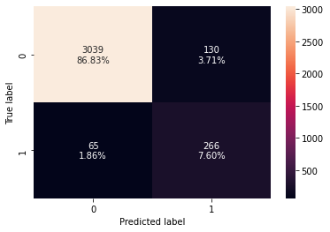

```python
# creating confusion matrix
confusion_matrix_sklearn_with_threshold(lg, X_train, y_train, threshold=manual_optimal_threshold)

log_reg_model_train_perf_threshold_manual = model_performance_classification_sklearn_with_threshold(
    lg, X_train, y_train, threshold=manual_optimal_threshold)

print("Train data performance:")
log_reg_model_train_perf_threshold_manual
```

```
Test data performance:
```

|  | Accuracy | Recall | Precision | F1 |
| --- | --- | --- | --- | --- |
| 0 | 0.941333 | 0.758389 | 0.684848 | 0.719745 |

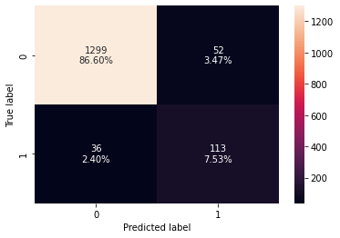

```python
# creating confusion matrix
confusion_matrix_sklearn_with_threshold(lg, X_test, y_test, threshold=manual_optimal_threshold)

log_reg_model_test_perf_threshold_manual = model_performance_classification_sklearn_with_threshold(
    lg, X_test, y_test, threshold=manual_optimal_threshold)

print("Test data performance:")
log_reg_model_test_perf_threshold_manual
```

## Decision Tree Model

```python
DT_model = DecisionTreeClassifier(criterion="gini", random_state=1)
DT_model.fit(X_train, y_train)
```

```
DecisionTreeClassifier(random_state=1)
```

|  | Accuracy | Recall | Precision | F1 |
| --- | --- | --- | --- | --- |
| 0 | 1.0 | 1.0 | 1.0 | 1.0 |

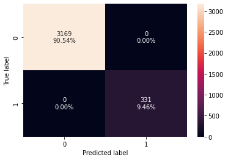

```python
# check DT model performance on train set
confusion_matrix_sklearn(DT_model, X_train, y_train)

decision_tree_perf_train = model_performance_classification_sklearn(DT_model, X_train, y_train)
decision_tree_perf_train
```

|  | Accuracy | Recall | Precision | F1 |
| --- | --- | --- | --- | --- |
| 0 | 0.977333 | 0.85906 | 0.907801 | 0.882759 |

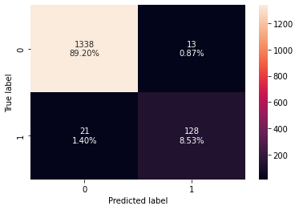

```python
# check DT model performance on test set
confusion_matrix_sklearn(DT_model, X_test, y_test)

decision_tree_perf_test = model_performance_classification_sklearn(DT_model, X_test, y_test)
decision_tree_perf_test
```

Even with grossly overfitting (train set all metrics are 1), the DT model performed better on the test data set than the most optimized Logistic Regression Model. We shall using pruning methods to further improve the model.

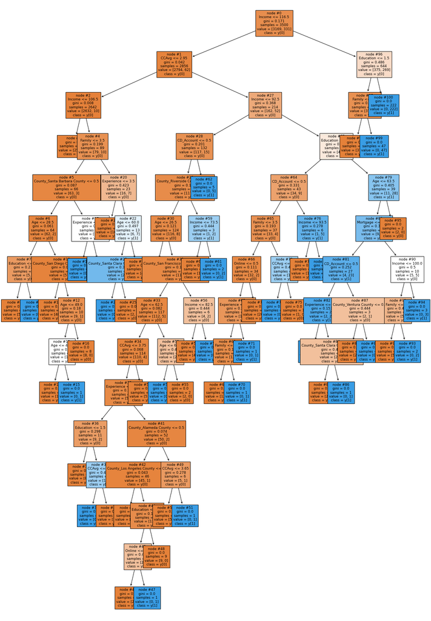

```python
# Visualizing the tree
column_names = list(X.columns)
feature_names = column_names

plt.figure(figsize=(20, 30))

out = tree.plot_tree(
    DT_model,
    feature_names=feature_names,
    filled=True,
    fontsize=9,
    node_ids=True,
    class_names=True,
)
for o in out:
    arrow = o.arrow_patch
    if arrow is not None:
        arrow.set_edgecolor("black")
        arrow.set_linewidth(1)
plt.show()
```

```python
# Text report showing the rules of a decision tree -
print(tree.export_text(DT_model, feature_names=feature_names, show_weights=True))
```

```
|--- Income <= 116.50
|   |--- CCAvg <= 2.95
|   |   |--- Income <= 106.50
|   |   |   |--- weights: [2553.00, 0.00] class: 0
|   |   |--- Income >  106.50
|   |   |   |--- Family <= 3.50
|   |   |   |   |--- County_Santa Barbara County <= 0.50
|   |   |   |   |   |--- Age <= 28.50
|   |   |   |   |   |   |--- Education <= 1.50
|   |   |   |   |   |   |   |--- weights: [5.00, 0.00] class: 0
|   |   |   |   |   |   |--- Education >  1.50
|   |   |   |   |   |   |   |--- weights: [0.00, 1.00] class: 1
|   |   |   |   |   |--- Age >  28.50
|   |   |   |   |   |   |--- County_San Diego County <= 0.50
|   |   |   |   |   |   |   |--- weights: [48.00, 0.00] class: 0
|   |   |   |   |   |   |--- County_San Diego County >  0.50
|   |   |   |   |   |   |   |--- Age <= 49.00
|   |   |   |   |   |   |   |   |--- Age <= 44.50
|   |   |   |   |   |   |   |   |   |--- weights: [1.00, 0.00] class: 0
|   |   |   |   |   |   |   |   |--- Age >  44.50
|   |   |   |   |   |   |   |   |   |--- weights: [0.00, 1.00] class: 1
|   |   |   |   |   |   |   |--- Age >  49.00
|   |   |   |   |   |   |   |   |--- weights: [8.00, 0.00] class: 0
|   |   |   |   |--- County_Santa Barbara County >  0.50
|   |   |   |   |   |--- Experience <= 16.50
|   |   |   |   |   |   |--- weights: [0.00, 1.00] class: 1
|   |   |   |   |   |--- Experience >  16.50
|   |   |   |   |   |   |--- weights: [1.00, 0.00] class: 0
|   |   |   |--- Family >  3.50
|   |   |   |   |--- Experience <= 3.50
|   |   |   |   |   |--- weights: [10.00, 0.00] class: 0
|   |   |   |   |--- Experience >  3.50
|   |   |   |   |   |--- Age <= 60.00
|   |   |   |   |   |   |--- County_Santa Clara County <= 0.50
|   |   |   |   |   |   |   |--- weights: [0.00, 7.00] class: 1
|   |   |   |   |   |   |--- County_Santa Clara County >  0.50
|   |   |   |   |   |   |   |--- weights: [2.00, 0.00] class: 0
|   |   |   |   |   |--- Age >  60.00
|   |   |   |   |   |   |--- weights: [4.00, 0.00] class: 0
|   |--- CCAvg >  2.95
```

[output cut: 81 more lines]

```
|   |   |   |   |   |   |   |   |--- weights: [5.00, 0.00] class: 0
|   |   |   |   |   |   |   |--- Family >  2.50
|   |   |   |   |   |   |   |   |--- weights: [0.00, 2.00] class: 1
|   |   |   |   |   |   |--- Income >  100.00
|   |   |   |   |   |   |   |--- weights: [0.00, 3.00] class: 1
|   |   |   |   |--- Age >  63.50
|   |   |   |   |   |--- weights: [2.00, 0.00] class: 0
|--- Income >  116.50
|   |--- Education <= 1.50
|   |   |--- Family <= 2.50
|   |   |   |--- weights: [375.00, 0.00] class: 0
|   |   |--- Family >  2.50
|   |   |   |--- weights: [0.00, 47.00] class: 1
|   |--- Education >  1.50
|   |   |--- weights: [0.00, 222.00] class: 1
```

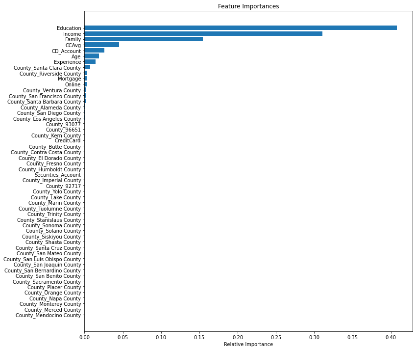

```python
importances = DT_model.feature_importances_
indices = np.argsort(importances)

plt.figure(figsize=(12, 12))
plt.title("Feature Importances")
plt.barh(range(len(indices)), importances[indices], align="center")
plt.yticks(range(len(indices)), [feature_names[i] for i in indices])
plt.xlabel("Relative Importance")
plt.show()
```

Education, Income, Family and CCAvg are top on the importance list, in that order. Let's try and reduce the overfitting by using GridSearch.

### GridSearch - Pre Pruning of our DT Model

```python
# type of classifier
estimator = DecisionTreeClassifier(random_state=1)

# Grid of parameters to choose from

parameters = {
    "max_depth": [None, 2, 3, 4, 5, 6, 7, 8, 9, 10, 11, 12, 13, 14, 15],
    "criterion": ["entropy", "gini"],
    "splitter": ["best", "random"],
    "min_impurity_decrease": [0.000001, 0.00001, 0.0001]
}

# Type of scoring used to compare parameter combinations
acc_scorer = make_scorer(recall_score)

# Run the grid search
grid_obj = GridSearchCV(estimator, parameters, scoring=acc_scorer, cv=5)
grid_obj = grid_obj.fit(X_train, y_train)

# Set the clf to the best combination of parameters
estimator = grid_obj.best_estimator_

# Fit the best algorithm to the data.
estimator.fit(X_train, y_train)
```

```
DecisionTreeClassifier(criterion='entropy', max_depth=4,
                       min_impurity_decrease=1e-06, random_state=1)
```

|  | Accuracy | Recall | Precision | F1 |
| --- | --- | --- | --- | --- |
| 0 | 0.988857 | 0.912387 | 0.967949 | 0.939347 |

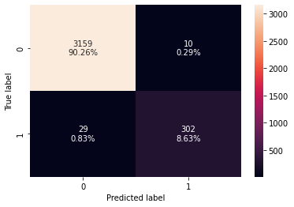

```python
# DT Model performance on Train data
confusion_matrix_sklearn(estimator, X_train, y_train)

decision_tree_tune_perf_train = model_performance_classification_sklearn(estimator, X_train, y_train)
decision_tree_tune_perf_train
```

|  | Accuracy | Recall | Precision | F1 |
| --- | --- | --- | --- | --- |
| 0 | 0.98 | 0.852349 | 0.940741 | 0.894366 |

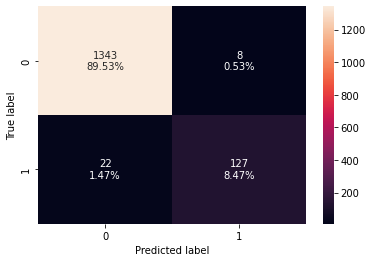

```python
# DT Model performance on test data
confusion_matrix_sklearn(estimator, X_test, y_test)

decision_tree_tune_perf_test = model_performance_classification_sklearn(estimator, X_test, y_test)
decision_tree_tune_perf_test
```

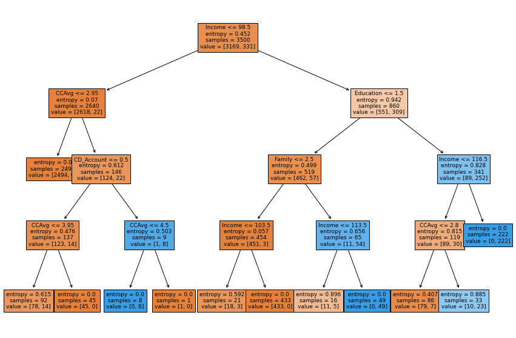

```python
plt.figure(figsize=(15, 10))
out = tree.plot_tree(
    estimator,
    feature_names=feature_names,
    filled=True,
    fontsize=9,
    node_ids=False,
    class_names=None,
)
for o in out:
    arrow = o.arrow_patch
    if arrow is not None:
        arrow.set_edgecolor("black")
        arrow.set_linewidth(1)
plt.show()
```

```python
print(tree.export_text(estimator, feature_names=feature_names, show_weights=True))
```

```
|--- Income <= 98.50
|   |--- CCAvg <= 2.95
|   |   |--- weights: [2494.00, 0.00] class: 0
|   |--- CCAvg >  2.95
|   |   |--- CD_Account <= 0.50
|   |   |   |--- CCAvg <= 3.95
|   |   |   |   |--- weights: [78.00, 14.00] class: 0
|   |   |   |--- CCAvg >  3.95
|   |   |   |   |--- weights: [45.00, 0.00] class: 0
|   |   |--- CD_Account >  0.50
|   |   |   |--- CCAvg <= 4.50
|   |   |   |   |--- weights: [0.00, 8.00] class: 1
|   |   |   |--- CCAvg >  4.50
|   |   |   |   |--- weights: [1.00, 0.00] class: 0
|--- Income >  98.50
|   |--- Education <= 1.50
|   |   |--- Family <= 2.50
|   |   |   |--- Income <= 103.50
|   |   |   |   |--- weights: [18.00, 3.00] class: 0
|   |   |   |--- Income >  103.50
|   |   |   |   |--- weights: [433.00, 0.00] class: 0
|   |   |--- Family >  2.50
|   |   |   |--- Income <= 113.50
|   |   |   |   |--- weights: [11.00, 5.00] class: 0
|   |   |   |--- Income >  113.50
|   |   |   |   |--- weights: [0.00, 49.00] class: 1
|   |--- Education >  1.50
|   |   |--- Income <= 116.50
|   |   |   |--- CCAvg <= 2.80
|   |   |   |   |--- weights: [79.00, 7.00] class: 0
|   |   |   |--- CCAvg >  2.80
|   |   |   |   |--- weights: [10.00, 23.00] class: 1
|   |   |--- Income >  116.50
|   |   |   |--- weights: [0.00, 222.00] class: 1
```

Observation:

- If income is below \$98.5k, customer has a CD_Account, and CCAvg is between \\$2.95k and \$4.50k, then customer will accept a personal loan, but if CCAvg is more than \\$4.50k or if they don't have a CD account, then customer will not accept a personal loan.

Other decision rules can be interpreted in a similar fashion.

Model did not improve with GridSearch because all parameters from test data (except for Precision, which increased by 4 points) are similar to the test performance of the unpruned tree. We do note, however, that training data performance is closer to the test data performance for this tree, as compared to the unpruned tree. Let's try post-pruning.

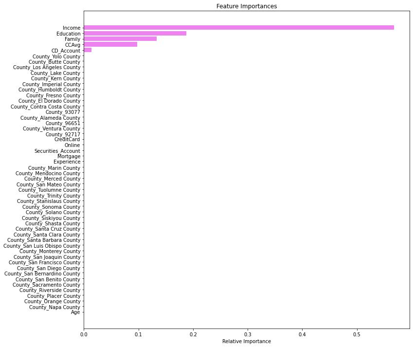

```python
importances = estimator.feature_importances_
indices = np.argsort(importances)

plt.figure(figsize=(12, 12))
plt.title("Feature Importances")
plt.barh(range(len(indices)), importances[indices], color="violet", align="center")
plt.yticks(range(len(indices)), [feature_names[i] for i in indices])
plt.xlabel("Relative Importance")
plt.show()
```

Similar to the unpruned tree, this DT model has income, family, education and CCAvg as top important columns, but in different proportions and order.

## Cost Complexity Pruning

```python
clf = DecisionTreeClassifier(random_state=1)
path = clf.cost_complexity_pruning_path(X_train, y_train)
ccp_alphas, impurities = path.ccp_alphas, path.impurities
```

```python
pd.DataFrame(path)
```

|  | ccp_alphas | impurities |
| --- | --- | --- |
| 0 | 0.000000 | 0.000000 |
| 1 | 0.000186 | 0.000559 |
| 2 | 0.000187 | 0.001121 |
| 3 | 0.000269 | 0.002195 |
| 4 | 0.000270 | 0.002735 |
| 5 | 0.000273 | 0.004371 |
| 6 | 0.000359 | 0.005447 |
| 7 | 0.000381 | 0.005828 |
| 8 | 0.000381 | 0.006209 |
| 9 | 0.000381 | 0.006590 |
| 10 | 0.000381 | 0.006971 |
| 11 | 0.000476 | 0.007447 |
| 12 | 0.000514 | 0.008988 |
| 13 | 0.000582 | 0.009571 |
| 14 | 0.000593 | 0.010756 |
| 15 | 0.000607 | 0.011363 |
| 16 | 0.000641 | 0.013928 |
| 17 | 0.000811 | 0.017985 |
| 18 | 0.001552 | 0.019536 |
| 19 | 0.002333 | 0.021869 |
| 20 | 0.003024 | 0.024893 |
| 21 | 0.003294 | 0.028187 |
| 22 | 0.006473 | 0.034659 |
| 23 | 0.023866 | 0.058525 |
| 24 | 0.056365 | 0.171255 |

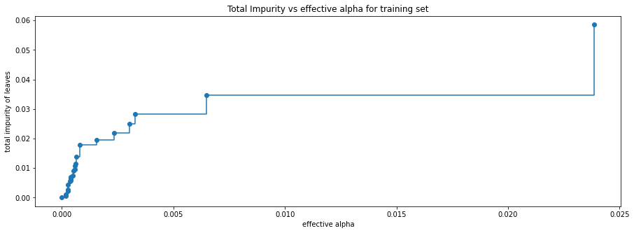

```python
fig, ax = plt.subplots(figsize=(15, 5))
ax.plot(ccp_alphas[:-1], impurities[:-1], marker="o", drawstyle="steps-post")
ax.set_xlabel("effective alpha")
ax.set_ylabel("total impurity of leaves")
ax.set_title("Total Impurity vs effective alpha for training set")
plt.show()
```

```python
clfs = []
for ccp_alpha in ccp_alphas:
    clf = DecisionTreeClassifier(
        random_state=1, ccp_alpha=ccp_alpha, class_weight={0: 0.15, 1: 0.85}
    )
    clf.fit(X_train, y_train)
    clfs.append(clf)
print(
    "Number of nodes in the last tree is: {} with ccp_alpha: {}".format(
        clfs[-1].tree_.node_count, ccp_alphas[-1]
    )
)
```

```
Number of nodes in the last tree is: 7 with ccp_alpha: 0.056364969335601575
```

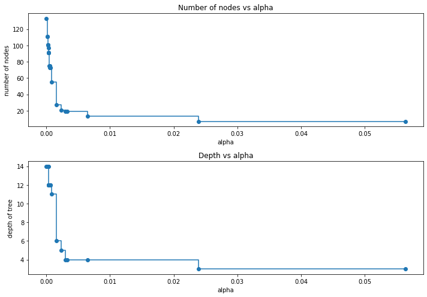

```python
node_counts = [clf.tree_.node_count for clf in clfs]
depth = [clf.tree_.max_depth for clf in clfs]
fig, ax = plt.subplots(2, 1, figsize=(10, 7))
ax[0].plot(ccp_alphas, node_counts, marker="o", drawstyle="steps-post")
ax[0].set_xlabel("alpha")
ax[0].set_ylabel("number of nodes")
ax[0].set_title("Number of nodes vs alpha")
ax[1].plot(ccp_alphas, depth, marker="o", drawstyle="steps-post")
ax[1].set_xlabel("alpha")
ax[1].set_ylabel("depth of tree")
ax[1].set_title("Depth vs alpha")
fig.tight_layout()
```

```python
recall_train = []
for clf in clfs:
    pred_train = clf.predict(X_train)
    values_train = recall_score(y_train, pred_train)
    recall_train.append(values_train)
```

```python
recall_test = []
for clf in clfs:
    pred_test = clf.predict(X_test)
    values_test = recall_score(y_test, pred_test)
    recall_test.append(values_test)
```

```python
train_scores = [clf.score(X_train, y_train) for clf in clfs]
test_scores = [clf.score(X_test, y_test) for clf in clfs]
```

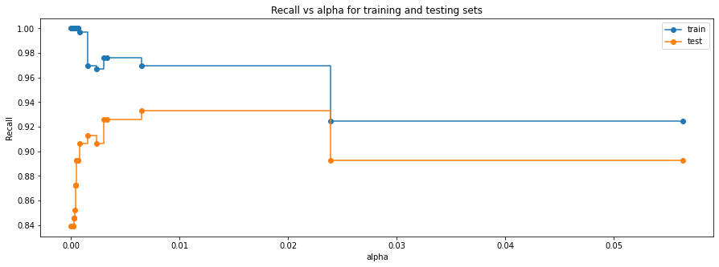

```python
fig, ax = plt.subplots(figsize=(15, 5))
ax.set_xlabel("alpha")
ax.set_ylabel("Recall")
ax.set_title("Recall vs alpha for training and testing sets")
ax.plot(
    ccp_alphas, recall_train, marker="o", label="train", drawstyle="steps-post",
)
ax.plot(ccp_alphas, recall_test, marker="o", label="test", drawstyle="steps-post")
ax.legend()
plt.show()
```

```python
print(f"Maximum value of recall is at \nalpha = { ccp_alphas[np.argmax(recall_test)] } ")
```

```
Maximum value of recall is at
alpha = 0.006472814718223818
```

```python
# creating the model where we get highest train and test recall
index_best_model = np.argmax(recall_test)
best_model = clfs[index_best_model]
print(best_model)
```

```
DecisionTreeClassifier(ccp_alpha=0.006472814718223818,
                       class_weight={0: 0.15, 1: 0.85}, random_state=1)
```

```python
best_model.fit(X_train, y_train)
```

```
DecisionTreeClassifier(ccp_alpha=0.006472814718223818,
                       class_weight={0: 0.15, 1: 0.85}, random_state=1)
```

|  | Accuracy | Recall | Precision | F1 |
| --- | --- | --- | --- | --- |
| 0 | 0.955714 | 0.969789 | 0.688841 | 0.805521 |

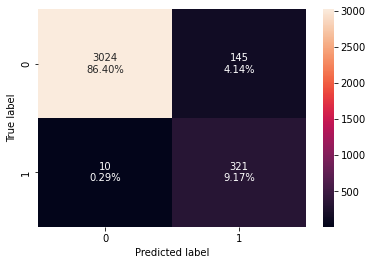

```python
confusion_matrix_sklearn(best_model, X_train, y_train)

decision_tree_cost_comp_train = model_performance_classification_sklearn(best_model, X_train, y_train)
decision_tree_cost_comp_train
```

|  | Accuracy | Recall | Precision | F1 |
| --- | --- | --- | --- | --- |
| 0 | 0.95 | 0.932886 | 0.681373 | 0.787535 |

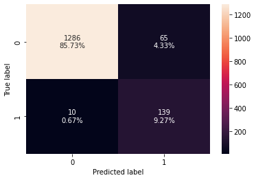

```python
confusion_matrix_sklearn(best_model, X_test, y_test)

decision_tree_cost_comp_test = model_performance_classification_sklearn(best_model, X_test, y_test)
decision_tree_cost_comp_test
```

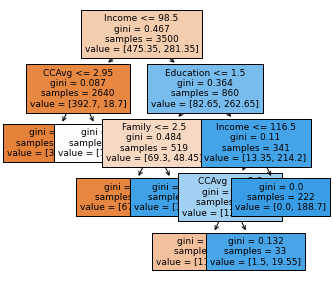

```python
plt.figure(figsize=(5, 5))

out = tree.plot_tree(
    best_model,
    feature_names=feature_names,
    filled=True,
    fontsize=9,
    node_ids=False,
    class_names=None,
)
for o in out:
    arrow = o.arrow_patch
    if arrow is not None:
        arrow.set_edgecolor("black")
        arrow.set_linewidth(1)
plt.show()
```

```python
print(tree.export_text(best_model, feature_names=feature_names, show_weights=True))
```

```
|--- Income <= 98.50
|   |--- CCAvg <= 2.95
|   |   |--- weights: [374.10, 0.00] class: 0
|   |--- CCAvg >  2.95
|   |   |--- weights: [18.60, 18.70] class: 1
|--- Income >  98.50
|   |--- Education <= 1.50
|   |   |--- Family <= 2.50
|   |   |   |--- weights: [67.65, 2.55] class: 0
|   |   |--- Family >  2.50
|   |   |   |--- weights: [1.65, 45.90] class: 1
|   |--- Education >  1.50
|   |   |--- Income <= 116.50
|   |   |   |--- CCAvg <= 2.80
|   |   |   |   |--- weights: [11.85, 5.95] class: 0
|   |   |   |--- CCAvg >  2.80
|   |   |   |   |--- weights: [1.50, 19.55] class: 1
|   |   |--- Income >  116.50
|   |   |   |--- weights: [0.00, 188.70] class: 1
```

```python
# train performance comparison

models_train_comp_df_DT = pd.concat(
    [
        decision_tree_perf_train.T,
        decision_tree_tune_perf_train.T,
        decision_tree_cost_comp_train.T,
    ],
    axis=1,
)
models_train_comp_df_DT.columns = [
    "Unpruned Decision Tree",
    "Prepruned Decision Tree",
    "Postpruned Decision Tree alpha=0.00647",
]
print("Train performance comparison:")
models_train_comp_df_DT
```

```
Train performance comparison:
```

|  | Unpruned Decision Tree | Prepruned Decision Tree | Postpruned Decision Tree alpha=0.00647 |
| --- | --- | --- | --- |
| Accuracy | 1.0 | 0.988857 | 0.955714 |
| Recall | 1.0 | 0.912387 | 0.969789 |
| Precision | 1.0 | 0.967949 | 0.688841 |
| F1 | 1.0 | 0.939347 | 0.805521 |

```python
# test performance comparison

models_test_comp_df_DT = pd.concat(
    [
        decision_tree_perf_test.T,
        decision_tree_tune_perf_test.T,
        decision_tree_cost_comp_test.T,
    ],
    axis=1,
)
models_test_comp_df_DT.columns = [
    "Unpruned Decision Tree",
    "Prepruned Decision Tree",
    "Postpruned Decision Tree alpha=0.00647",
]
print("Test performance comparison:")
models_test_comp_df_DT
```

```
Test performance comparison:
```

|  | Unpruned Decision Tree | Prepruned Decision Tree | Postpruned Decision Tree alpha=0.00647 |
| --- | --- | --- | --- |
| Accuracy | 0.977333 | 0.980000 | 0.950000 |
| Recall | 0.859060 | 0.852349 | 0.932886 |
| Precision | 0.907801 | 0.940741 | 0.681373 |
| F1 | 0.882759 | 0.894366 | 0.787535 |

The post pruned decision tree gives us the highest recall. However, its precision and F-1 Score are much lower than the pre-pruned and unpruned model trees.

## Conclusions & Comparing Logistic vs Decision Tree Model Performance

```python
# test performance comparison - Logistic Regression Models
models_test_comp_df = pd.concat(
    [
        log_reg_model_test_perf.T,
        log_reg_model_test_perf_threshold_auc_roc.T,
        log_reg_model_test_perf_threshold_curve.T,
        log_reg_model_train_perf_threshold_manual.T
    ],
    axis=1,
)
models_test_comp_df.columns = [
    "Logistic Regression sklearn - 0.50 Threshold",
    "Logistic Regression - 0.122 Threshold",
    "Logistic Regression - 0.32 Threshold",
    "Logistic Regression - 0.25 Threshold"
]
print("Logistic Regression | Test performance comparison:")
models_test_comp_df
```

```
Logistic Regression | Test performance comparison:
```

[output not shown]

```python
models_test_comp_df_DT = pd.concat(
    [
        decision_tree_perf_test.T,
        decision_tree_tune_perf_test.T,
        decision_tree_cost_comp_test.T,
    ],
    axis=1,
)
models_test_comp_df_DT.columns = [
    "Unpruned Decision Tree",
    "Prepruned Decision Tree",
    "Postpruned Decision Tree alpha=0.00647",
]
print("Decision Tree | Test performance comparison:")
models_test_comp_df_DT
```

```
Decision Tree | Test performance comparison:
```

|  | Unpruned Decision Tree | Prepruned Decision Tree | Postpruned Decision Tree alpha=0.00647 |
| --- | --- | --- | --- |
| Accuracy | 0.977333 | 0.980000 | 0.950000 |
| Recall | 0.859060 | 0.852349 | 0.932886 |
| Precision | 0.907801 | 0.940741 | 0.681373 |
| F1 | 0.882759 | 0.894366 | 0.787535 |

- Our logistic regression model predicted the data to an extent. Even then, our recall was improved to be up to 86%.
- Our Decision Tree model had a recall of 85.9% before pruning, and we know this was overfitting the data.
- Prepruning only helped increase our precision value, which is still a better model. However, since recall was the same, it was not a better model from the bank's perspective.
- Postpruning increased recall to 93%, the highest value yet. However, we lose precision and F1 score significantly in this tradeoff.

All our models helped us understand and predict the data in different ways. A few common things we note are that education, family, income, CCAvg and CD_Account were the most important factors in determining whether a customer would accept a personal loan from the bank. Identifying and honing in to these metrics can help the bank better target customers that would potentially turn into asset customers.

Some conclusions from the Decision Tree classification:

- if income is low, then CCAvg needs to be higher if personal loan is to be accepted.
- if income is mid-range and education is high, then CCAvg needs to be above \$2.8k for personal loan to be accepted.
- if income is high and education is low, then family must be large (>=3) for personal loan to be accepted.
- if incoem and education both are high, then personal loan will be accepted.

Points of improvement:

- The data does not have enough information on metrics when personal loan is accepted (around 9.6%). Having more data points with a higher success rate will help in tuning a more accurate model with a higher recall.